# Project work

TKO_7093  
Autumn 2022  
Peppi-Lotta Saari

```python
import pandas as pd
import numpy as np
import matplotlib.pyplot as plt
import seaborn as sns
import plotly.express as px
from sklearn.decomposition import PCA
import sklearn.preprocessing as sp
import sklearn.decomposition as sd
import scipy
from scipy import stats
```

## Data preparation

```python
# load data
loc = r'bikes.data'
original_data = pd.read_csv(loc, sep=",", header=0)
original_data
```

|  | ticket | cost | month | location_from | location_to | duration | distance | assistance | energy_used | energy_collected |
| --- | --- | --- | --- | --- | --- | --- | --- | --- | --- | --- |
| 0 | season | 0.00 | 7 | TEATTERI | TEATTERI | 3 | 0 | 0 | 0.0 | 0.0 |
| 1 | single | 0.35 | 7 | TORI | TEATTERI | 416 | 820 | 1 | 7.5 | 0.6 |
| 2 | season | 0.00 | 8 | TORI | SATAMA | 721 | 1230 | 0 | 0.0 | 2.1 |
| 3 | single | 0.25 | 5 | TEATTERI | TORI | 261 | 720 | 0 | 0.0 | 1.2 |
| 4 | season | 0.00 | 5 | TEATTERI | TORI | 382 | 710 | 1 | 3.3 | 0.9 |
| ... | ... | ... | ... | ... | ... | ... | ... | ... | ... | ... |
| 1995 | single | 0.40 | 8 | KYS | TORI | 420 | 1940 | 1 | 10.3 | 6.0 |
| 1996 | single | 0.65 | 7 | VÄINÖLÄNNIEMI | SATAMA | 720 | 1020 | 0 | 0.0 | 0.0 |
| 1997 | single | 0.15 | 9 | TORI | TEATTERI | 172 | 730 | 1 | 6.6 | 0.3 |
| 1998 | season | 0.00 | 7 | SNELLMANIA | MICROTEKNIA | 211 | 450 | 0 | 0.0 | 0.3 |
| 1999 | single | 1.00 | 5 | TEATTERI | TORI | 1166 | 680 | 1 | 3.4 | 2.4 |

2000 rows × 10 columns

```python
categories =['ticket', 'month', 'location_from', 'location_to', 'assistance', ]

# print out all unique valus for categorial values
print(original_data[categories].apply(lambda col: col.unique()))
```

```
ticket                                   [season, single, savonia]
month                                       [7, 8, 5, 6, 9, 10, 4]
location_from    [TEATTERI, TORI, MICROTEKNIA, RYPYSUO, SATAMA,...
location_to      [TEATTERI, SATAMA, TORI, KYS, VÄINÖLÄNNIEMI, R...
assistance                                                  [0, 1]
dtype: object
```

```python
# Making categorial values categorial
for c in categories:
    original_data[c] = pd.Categorical(original_data[c])
```

```python
vars_with_na = [var for var in original_data.columns if original_data[var].isnull().sum() > 0]
print (vars_with_na)
```

```
[]
```

Original_data doesn't have obvious deficiencies at this point.

I printed out the unique values of categorial variables to see if the value naming is consistens and so that I can list them out in the next paragraph under the header "Properties of variables". Categorial variables all have consistens values and names. I made categorial values have the dtype Categorial so they are easily callable later in the project.

I tested if original_data has NaN-values which it didn't. No further action needed with quantitative values at this point.

### Properties of variables

#### ticket

- Ticket type
- Categorial->Nominal
- Values: single/season/savonia

#### cost

- paid fee in euros
- quantitative->Ratio
- euros (€) >= 0

#### month

- calendar month during which the trip was made
- Categorial->Ordinal
- Values: 4, 5, 6, 7, 8, 9, 10 (april, may, june, july, august, september, october)

#### location_from

- start location of the trip
- Categorial->Nominal
- Values: 'TEATTERI', 'TORI', 'MICROTEKNIA', 'RYPYSUO', 'SATAMA', 'KYS', 'SNELLMANIA', 'UIMAHALLI', 'VÄINÖLÄNNIEMI' ja 'PETONEN'

#### location_to

- end location of the trip
- Categorial->Nominal
- Value: 'TEATTERI', 'SATAMA', 'TORI', 'KYS', 'VÄINÖLÄNNIEMI', 'RYPYSUO', 'MICROTEKNIA', 'SNELLMANIA', 'UIMAHALLI' ja 'PETONEN

#### duration

- travel time in seconds
- quantitative->Ratio
- seconds (s) >= 0

#### distance

- travel distance in meters
- quantitative->Ratio
- meters (m) >= 0

#### assistance

- status of electric assistance (0 = disabled, 1 = enabled)
- Categorial->Nominal->Indicator
- On/Off

#### energy_used

- energy consumed by the bike in watt-hours
- Quantitative->Ratio
- watt-hours (Wh) >= 0

#### energy_collected

- energy collected by the bike in watt-hours
- Quantitative->Ratio
- watt-hours (Wh) >= 0

### Basic statistics

#### Quantitative variables

```python
quantitative_data = original_data.select_dtypes(include='number')
display(quantitative_data.describe())
```

|  | cost | duration | distance | energy_used | energy_collected |
| --- | --- | --- | --- | --- | --- |
| count | 2000.00000 | 2000.000000 | 2000.00000 | 2000.000000 | 2000.000000 |
| mean | 0.22345 | 539.975500 | 1721.93000 | 11.761300 | 4.389300 |
| std | 0.47570 | 593.810888 | 2017.79918 | 15.573439 | 5.990604 |
| min | 0.00000 | 1.000000 | -3320.00000 | 0.000000 | 0.000000 |
| 25% | 0.00000 | 144.750000 | 40.00000 | 0.000000 | 0.000000 |
| 50% | 0.00000 | 400.000000 | 1130.00000 | 7.100000 | 2.400000 |
| 75% | 0.30000 | 736.750000 | 2572.50000 | 18.500000 | 6.900000 |
| max | 6.95000 | 8292.000000 | 19740.00000 | 184.300000 | 91.500000 |

```python
# Correlation
correlation = quantitative_data.corr(method="spearman")
display(correlation)
```

|  | cost | duration | distance | energy_used | energy_collected |
| --- | --- | --- | --- | --- | --- |
| cost | 1.000000 | 0.192712 | 0.204010 | 0.115504 | 0.167586 |
| duration | 0.192712 | 1.000000 | 0.879118 | 0.751726 | 0.768381 |
| distance | 0.204010 | 0.879118 | 1.000000 | 0.850034 | 0.866802 |
| energy_used | 0.115504 | 0.751726 | 0.850034 | 1.000000 | 0.750696 |
| energy_collected | 0.167586 | 0.768381 | 0.866802 | 0.750696 | 1.000000 |

#### Categorial variables

```python
#frequencies for categorial values
categorial_data = original_data.select_dtypes(exclude='number')
for c in categorial_data:
        absolute = original_data[c].value_counts().to_frame()
        relative = original_data[c].value_counts(normalize=True).to_frame()
        result = pd.concat([absolute, relative], axis=1)
        result.set_axis(['Frequency', 'Relative'], axis=1, inplace=True)
        result = result.style.set_caption(c)
        display(result)
```

ticket

|  | Frequency | Relative |
| --- | --- | --- |
| season | 893 | 0.446500 |
| single | 889 | 0.444500 |
| savonia | 218 | 0.109000 |

month

|  | Frequency | Relative |
| --- | --- | --- |
| 6 | 488 | 0.244000 |
| 7 | 406 | 0.203000 |
| 5 | 380 | 0.190000 |
| 9 | 256 | 0.128000 |
| 8 | 230 | 0.115000 |
| 10 | 197 | 0.098500 |
| 4 | 43 | 0.021500 |

location_from

|  | Frequency | Relative |
| --- | --- | --- |
| TORI | 673 | 0.336500 |
| SATAMA | 321 | 0.160500 |
| MICROTEKNIA | 202 | 0.101000 |
| TEATTERI | 171 | 0.085500 |
| VÄINÖLÄNNIEMI | 171 | 0.085500 |
| KYS | 142 | 0.071000 |
| SNELLMANIA | 110 | 0.055000 |
| RYPYSUO | 96 | 0.048000 |
| UIMAHALLI | 60 | 0.030000 |
| PETONEN | 54 | 0.027000 |

location_to

|  | Frequency | Relative |
| --- | --- | --- |
| TORI | 756 | 0.378000 |
| SATAMA | 323 | 0.161500 |
| MICROTEKNIA | 191 | 0.095500 |
| TEATTERI | 165 | 0.082500 |
| VÄINÖLÄNNIEMI | 158 | 0.079000 |
| SNELLMANIA | 112 | 0.056000 |
| KYS | 105 | 0.052500 |
| RYPYSUO | 85 | 0.042500 |
| PETONEN | 57 | 0.028500 |
| UIMAHALLI | 48 | 0.024000 |

assistance

|  | Frequency | Relative |
| --- | --- | --- |
| 1 | 1633 | 0.816500 |
| 0 | 367 | 0.183500 |

### Visualisation of the distribution of variables

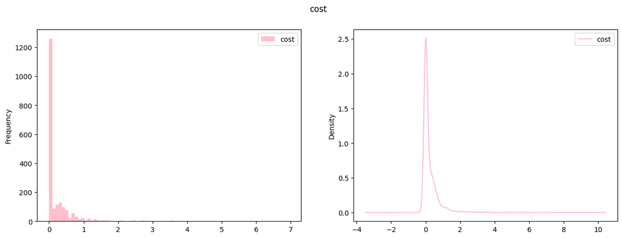

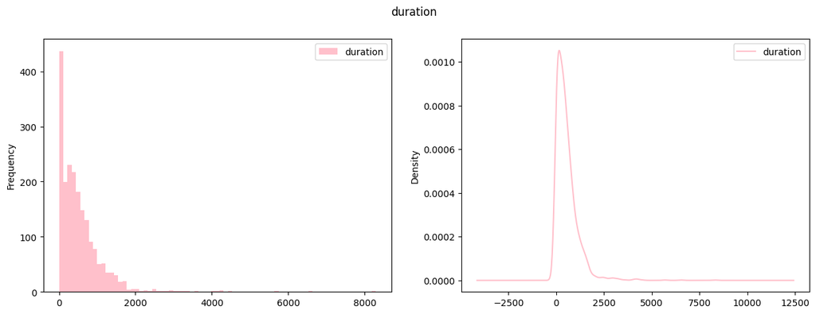

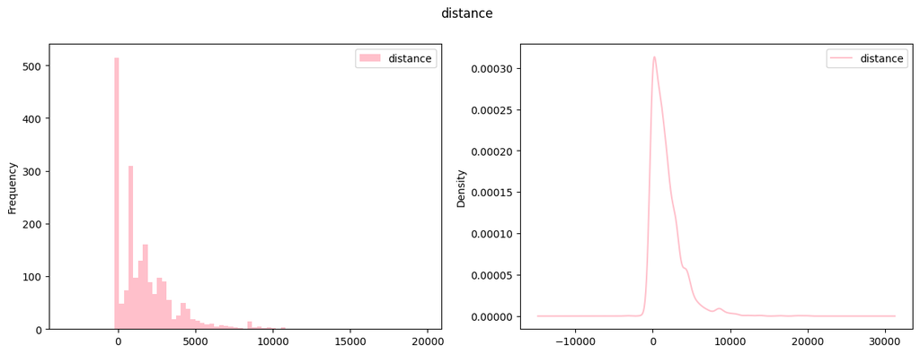

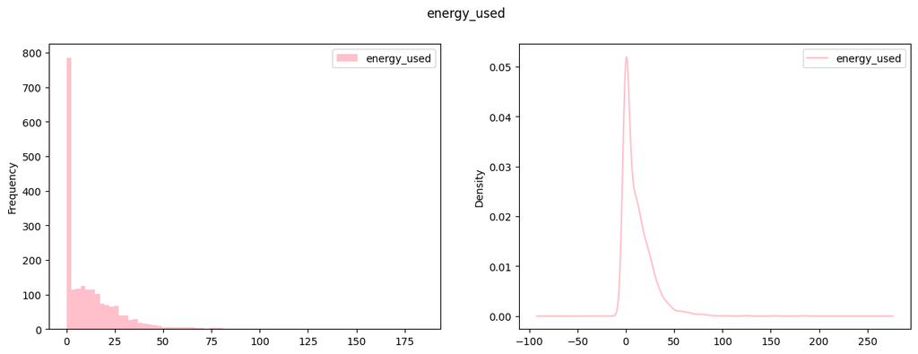

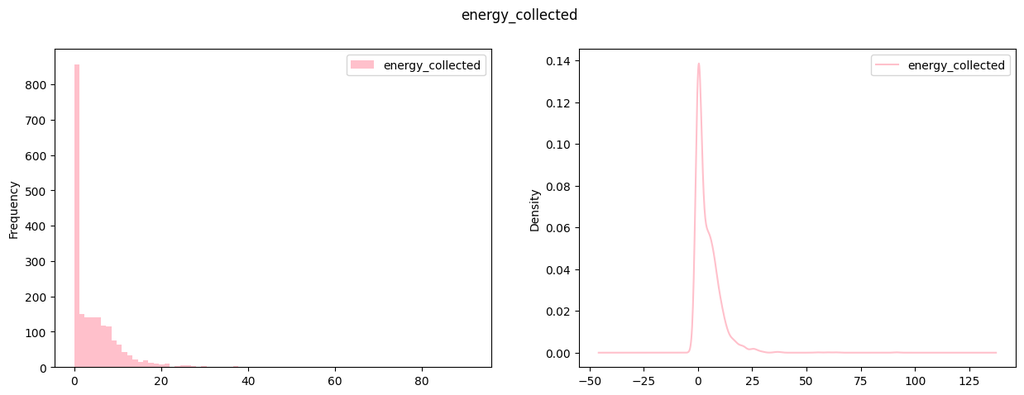

```python
# Density plot and histograms for quantitativa values
for q in quantitative_data:
    fig, axs = plt.subplots(1, 2, figsize=(15,5))
    quantitative_data[q].plot(kind="hist", bins=75, ax=axs[0], color="pink", legend=True)
    quantitative_data[q].plot(kind='density', ax=axs[1], color="pink", legend=True)
    fig.suptitle(q)
```

```
ticket
```

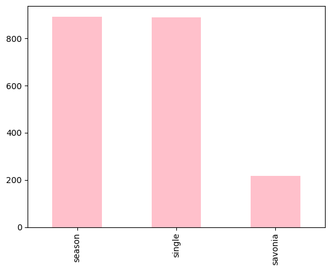

```
month
```

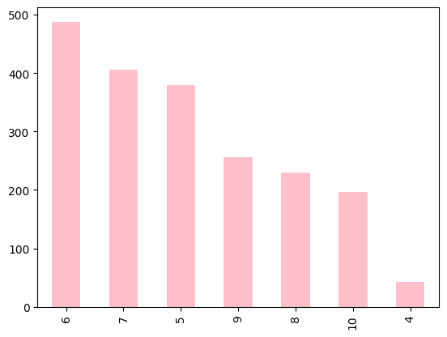

```
location_from
```

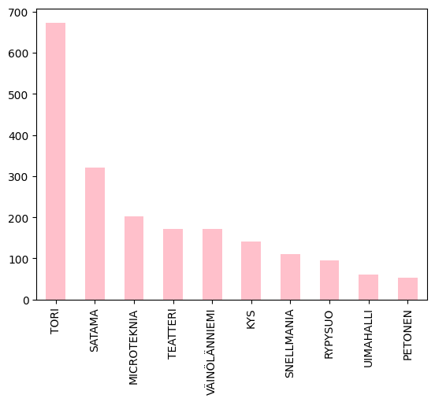

```
location_to
```

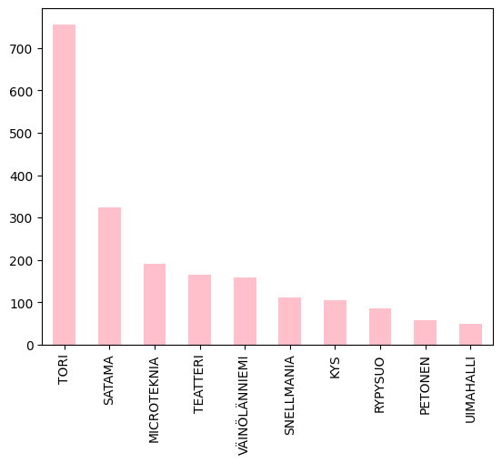

```
assistance
```

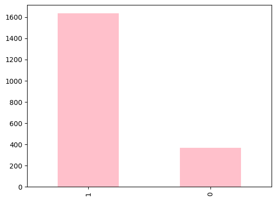

```python
# bar plot for categorial variables
for c in categorial_data:
    print(c)
    categorial_data[c].value_counts().plot(kind='bar', color="pink")
    plt.show()
```

### Invalid values

Distance column has nagative values. Otherwise data seems complete and intact. Distance should never be negative in this situation. Here we determine the best action for these negative values.

```python
# display the rows with the negative distances
print("Negative:")
dist_neg_data = original_data.loc[original_data['distance'] < 0 ]
display(dist_neg_data)

# original_data without the rows with negative distances
dist_pos_data = original_data.loc[original_data['distance'] >= 0 ].reset_index()

print("dist_pos_data normality check:", stats.shapiro(dist_pos_data['distance']))
# check if negative values turned to positive are likely to come from the same dataset as positive values
# Unpaired and not normal -> Mann-Whitney U test
neg_list = dist_neg_data['distance'].copy()
pos_list = []
for i in neg_list:
   pos_list.append(i * (-1))
print(pos_list)
print(stats.mannwhitneyu(dist_pos_data['distance'], pos_list))

data = dist_pos_data.copy()
data
```

```
Negative:
```

|  | ticket | cost | month | location_from | location_to | duration | distance | assistance | energy_used | energy_collected |
| --- | --- | --- | --- | --- | --- | --- | --- | --- | --- | --- |
| 457 | single | 0.10 | 5 | VÄINÖLÄNNIEMI | VÄINÖLÄNNIEMI | 77 | -90 | 1 | 0.0 | 0.0 |
| 537 | season | 0.00 | 5 | VÄINÖLÄNNIEMI | VÄINÖLÄNNIEMI | 68 | -30 | 1 | 0.1 | 0.0 |
| 567 | season | 0.00 | 5 | TEATTERI | TEATTERI | 78 | -20 | 1 | 0.0 | 0.0 |
| 689 | season | 0.00 | 10 | TORI | TORI | 96 | -40 | 1 | 1.9 | 0.3 |
| 801 | single | 0.15 | 8 | KYS | KYS | 133 | -110 | 1 | 0.0 | 0.0 |
| 996 | single | 1.15 | 8 | TORI | RYPYSUO | 1375 | -3320 | 1 | 0.0 | 0.0 |
| 1244 | single | 0.45 | 8 | VÄINÖLÄNNIEMI | TORI | 502 | -1340 | 1 | 0.0 | 0.0 |
| 1347 | single | 0.20 | 5 | VÄINÖLÄNNIEMI | VÄINÖLÄNNIEMI | 203 | -30 | 1 | 0.1 | 0.0 |
| 1674 | savonia | 0.00 | 10 | KYS | KYS | 70 | -10 | 1 | 0.0 | 0.0 |
| 1683 | season | 0.00 | 5 | TEATTERI | TEATTERI | 160 | -20 | 1 | 0.1 | 0.0 |
| 1839 | single | 0.05 | 5 | TEATTERI | TEATTERI | 58 | -20 | 1 | 0.0 | 0.0 |

```
dist_pos_data normality check: ShapiroResult(statistic=0.7761672735214233, pvalue=0.0)
[90, 30, 20, 40, 110, 3320, 1340, 30, 10, 20, 20]
MannwhitneyuResult(statistic=14796.5, pvalue=0.04243875422929495)
```

|  | index | ticket | cost | month | location_from | location_to | duration | distance | assistance | energy_used | energy_collected |
| --- | --- | --- | --- | --- | --- | --- | --- | --- | --- | --- | --- |
| 0 | 0 | season | 0.00 | 7 | TEATTERI | TEATTERI | 3 | 0 | 0 | 0.0 | 0.0 |
| 1 | 1 | single | 0.35 | 7 | TORI | TEATTERI | 416 | 820 | 1 | 7.5 | 0.6 |
| 2 | 2 | season | 0.00 | 8 | TORI | SATAMA | 721 | 1230 | 0 | 0.0 | 2.1 |
| 3 | 3 | single | 0.25 | 5 | TEATTERI | TORI | 261 | 720 | 0 | 0.0 | 1.2 |
| 4 | 4 | season | 0.00 | 5 | TEATTERI | TORI | 382 | 710 | 1 | 3.3 | 0.9 |
| ... | ... | ... | ... | ... | ... | ... | ... | ... | ... | ... | ... |
| 1984 | 1995 | single | 0.40 | 8 | KYS | TORI | 420 | 1940 | 1 | 10.3 | 6.0 |
| 1985 | 1996 | single | 0.65 | 7 | VÄINÖLÄNNIEMI | SATAMA | 720 | 1020 | 0 | 0.0 | 0.0 |
| 1986 | 1997 | single | 0.15 | 9 | TORI | TEATTERI | 172 | 730 | 1 | 6.6 | 0.3 |
| 1987 | 1998 | season | 0.00 | 7 | SNELLMANIA | MICROTEKNIA | 211 | 450 | 0 | 0.0 | 0.3 |
| 1988 | 1999 | single | 1.00 | 5 | TEATTERI | TORI | 1166 | 680 | 1 | 3.4 | 2.4 |

1989 rows × 11 columns

There are 11 rows where the distance traveled is negative. The rows seem have all the other data correctly displayed. I did a check with Mann_whitney U test to check if negative values turned to positive are likely to come from the same dataset as the other already positive values alone. P-value was 0.042. Statistical evidence shows that the values are not like from the same data set. Based on this I will exclude the rows with negative values.

## Data exploration

### Total distance travelled, the total time travelled, and the total amount of fees paid per ticket type

```python
# dataframes for ticket types
season = data.loc[data['ticket'] == 'season'].reset_index()
single = data.loc[data['ticket'] == 'single'].reset_index()
savonia = data.loc[data['ticket'] == 'savonia'].reset_index()
```

```python
# total distance in meters
print("Distance")
print ("Season", season['distance'].sum(), "m")
print ("Single", single['distance'].sum(), "m")
print ("Savonia", savonia['distance'].sum(), "m")
print ("Total over all ticket types", savonia['distance'].sum()+single['distance'].sum()+season['distance'].sum(), "m")
```

```
Distance
Season 1419140 m
Single 1621170 m
Savonia 408580 m
Total over all ticket types 3448890 m
```

```python
# total time travelled in seconds
print("Duration")
print ("Season", season['duration'].sum(), "s")
print ("Single", single['duration'].sum(), "s")
print ("Savonia", savonia['duration'].sum(), "s")
print ("Total over all ticket types", savonia['duration'].sum()+single['duration'].sum()+season['duration'].sum(), "s")
```

```
Duration
Season 459241 s
Single 495342 s
Savonia 122548 s
Total over all ticket types 1077131 s
```

```python
# total amount of fees as euros
print("Cost")
print ("Season", season['cost'].sum(), "€")
print ("Single", single['cost'].sum(), "€")
print ("Savonia", savonia['cost'].sum(), "€")
print ("Total over all ticket types", savonia['cost'].sum()+single['cost'].sum()+season['cost'].sum(), "€")
```

```
Cost
Season 8.0 €
Single 436.79999999999995 €
Savonia 0.0 €
Total over all ticket types 444.79999999999995 €
```

### Mean distance travelled, the mean energy consumed, and the mean energy collected per status of assistance.

```python
# selection with and without assistance
assistance = data.loc[data['assistance'] == 1].reset_index()
no_assistance = data.loc[data['assistance'] == 0].reset_index()
```

```python
# Means with assistance
print("With assistance")
print('Distance mean :', assistance['distance'].mean())
print('Energy used mean :', assistance['energy_used'].mean())
print('Energy collected mean :', assistance['energy_collected'].mean())
```

```
With assistance
Distance mean : 1928.6683107274969
Energy used mean : 14.500863131935883
Energy collected mean : 5.0360049321824905
```

```python
# Means with no assistance
print("Without assistance")
print('Distance mean :', no_assistance['distance'].mean())
print('Energy used mean :', no_assistance['energy_used'].mean())
print('Energy collected mean :', no_assistance['energy_collected'].mean())
```

```
Without assistance
Distance mean : 873.5422343324251
Energy used mean : 0.0
Energy collected mean : 1.6618528610354222
```

**Distance:** The mean of distance travelled with out assitance is **0.45** times the distance travelled with assistance. Cyclists seem to be likely to travel much greater distances with electrical assistance.  
**Energy used:** Energy used with out assistance is 0. This is to be expected as the assistance is the only part that consumes energy. If this wasn't 0 when assistance is 0 it would indicate that the data has invalid mesurements regarding the energy collected.  
**Energy collected:** Energy collected when asistance is not in use is about **0.33** of the energy collected with assistance on. This is most likely due to the fact that when the assistance is not in use the travel distances are much shorter.

### Three most popular locations per ticket type in terms of the number of trips that either started or ended at the location

The dataframes are sorted by the sum of from and to locations. So the top three rows of the dataframes in this section represent the most popular location per ticket type.

```python
# season
season_from = season['location_from'].value_counts().to_frame()
season_to = season['location_to'].value_counts().to_frame()

season_locations = season_from.join(season_to)
season_locations['sum'] = season_locations['location_from'] + season_locations['location_to']

display(season_locations.sort_values(by=['sum'], ascending=False))
```

|  | location_from | location_to | sum |
| --- | --- | --- | --- |
| TORI | 297 | 332 | 629 |
| SATAMA | 142 | 146 | 288 |
| VÄINÖLÄNNIEMI | 74 | 88 | 162 |
| TEATTERI | 80 | 67 | 147 |
| MICROTEKNIA | 72 | 61 | 133 |
| KYS | 67 | 57 | 124 |
| RYPYSUO | 47 | 40 | 87 |
| SNELLMANIA | 46 | 40 | 86 |
| PETONEN | 33 | 32 | 65 |
| UIMAHALLI | 31 | 26 | 57 |

```python
# single
single_from = single['location_from'].value_counts().to_frame()
single_to = single['location_to'].value_counts().to_frame()

single_locations = single_from.join(single_to)
single_locations['sum'] = single_locations['location_from'] + single_locations['location_to']

display(single_locations.sort_values(by=['sum'], ascending=False))
```

|  | location_from | location_to | sum |
| --- | --- | --- | --- |
| TORI | 314 | 355 | 669 |
| SATAMA | 156 | 158 | 314 |
| TEATTERI | 77 | 80 | 157 |
| VÄINÖLÄNNIEMI | 89 | 65 | 154 |
| MICROTEKNIA | 56 | 64 | 120 |
| KYS | 65 | 32 | 97 |
| SNELLMANIA | 42 | 50 | 92 |
| RYPYSUO | 43 | 37 | 80 |
| PETONEN | 19 | 23 | 42 |
| UIMAHALLI | 22 | 19 | 41 |

```python
# savonia
savonia_from = savonia['location_from'].value_counts().to_frame()
savonia_to = savonia['location_to'].value_counts().to_frame()

savonia_locations = savonia_from.join(savonia_to)
savonia_locations['sum'] = savonia_locations['location_from'] + savonia_locations['location_to']

display(savonia_locations.sort_values(by=['sum'], ascending=False))
```

|  | location_from | location_to | sum |
| --- | --- | --- | --- |
| MICROTEKNIA | 74 | 66 | 140 |
| TORI | 60 | 67 | 127 |
| SNELLMANIA | 22 | 22 | 44 |
| SATAMA | 23 | 19 | 42 |
| TEATTERI | 11 | 15 | 26 |
| KYS | 8 | 14 | 22 |
| RYPYSUO | 6 | 7 | 13 |
| UIMAHALLI | 7 | 3 | 10 |
| VÄINÖLÄNNIEMI | 4 | 2 | 6 |
| PETONEN | 2 | 2 | 4 |

### Visualisation of monthly rental activity per ticket type in terms of total distance travelled

```python
# get months
months = data['month'].unique().sort_values()
print(months)
```

```
[4, 5, 6, 7, 8, 9, 10]
Categories (7, int64): [4, 5, 6, 7, 8, 9, 10]
```

```python
# name months
month_names = {4: 'April', 5: 'May', 6: 'June', 7: 'July', 8: 'August', 9: 'September', 10: 'October' }
```

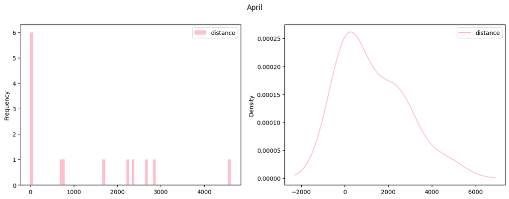

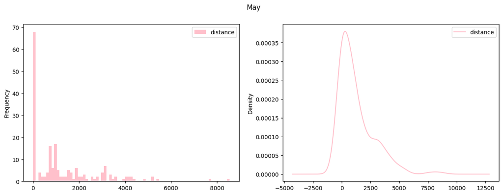

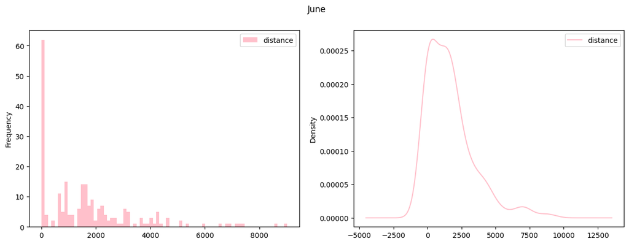

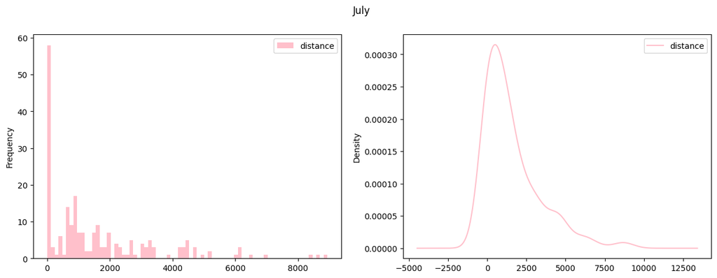

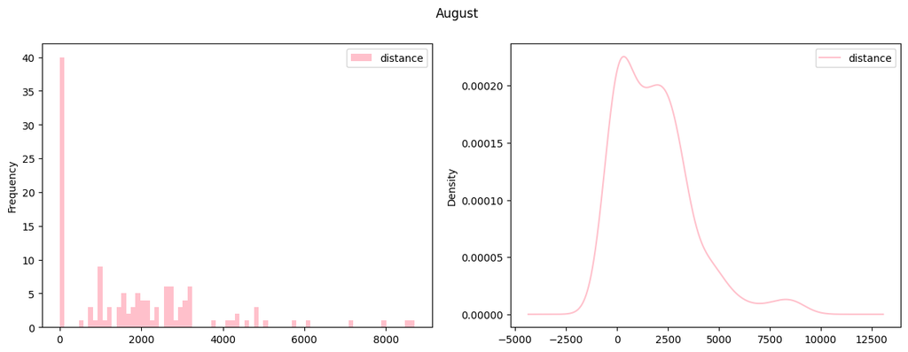

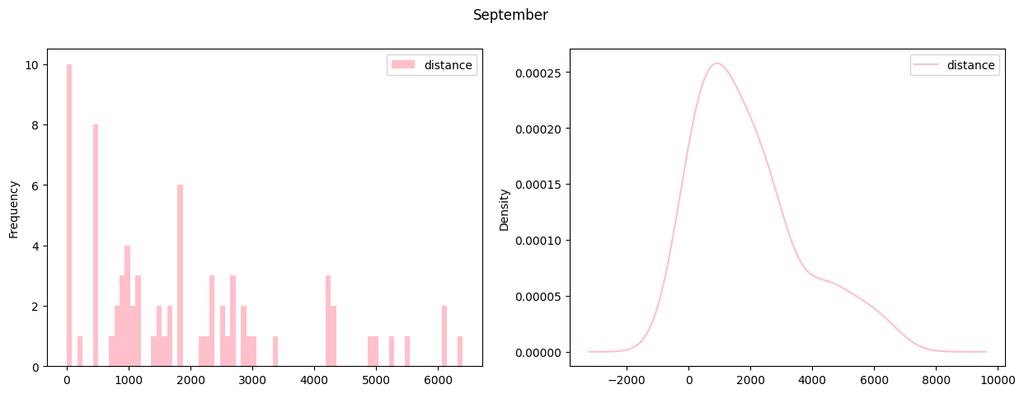

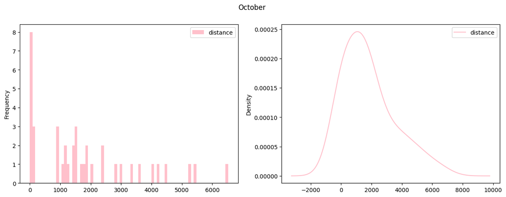

```python
# season
for m in months:
    season_month = season.loc[season['month'] == m]
    fig, axs = plt.subplots(1, 2, figsize=(15,5))
    season_month['distance'].plot(kind='hist',bins=75, ax=axs[0], color="pink", legend=True)
    season_month['distance'].plot(kind='density', ax=axs[1], color="pink", legend=True)
    fig.suptitle(month_names[m])
```

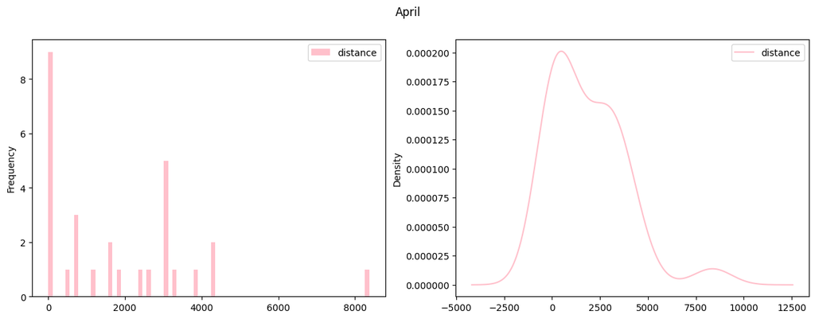

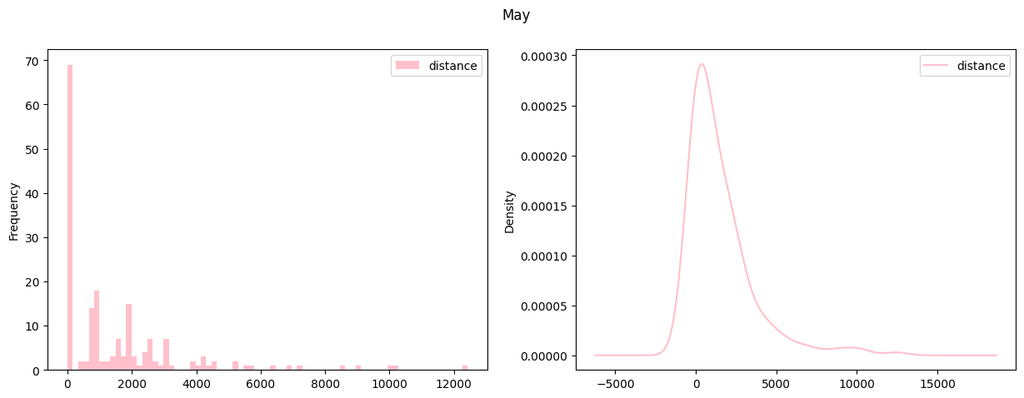

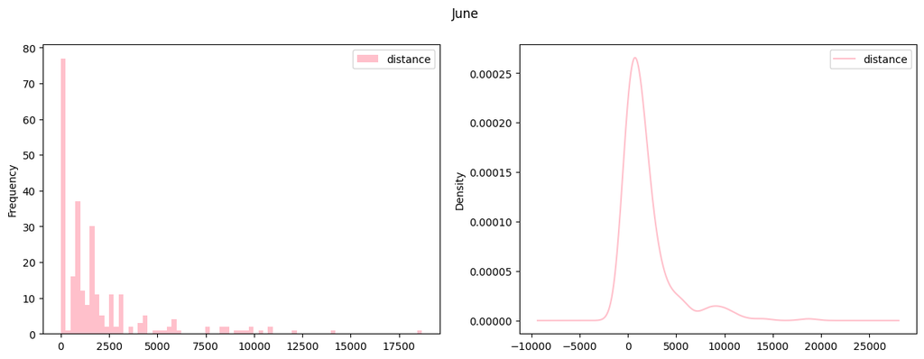

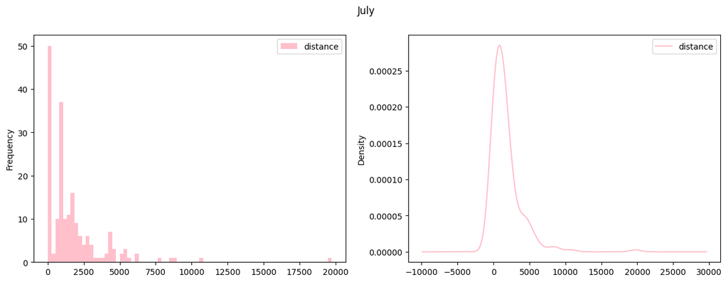

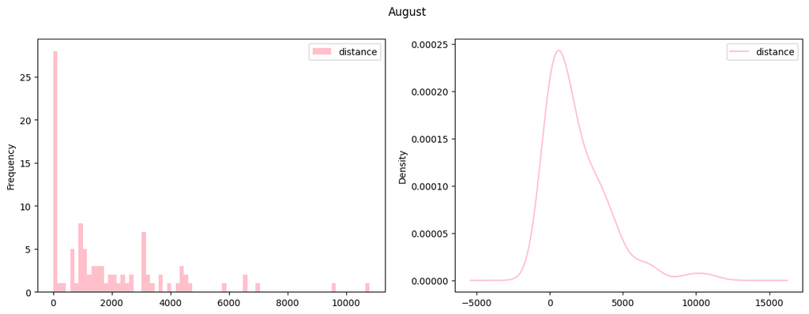

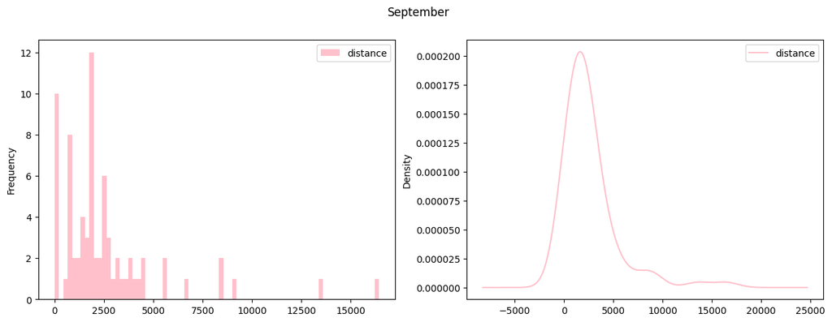

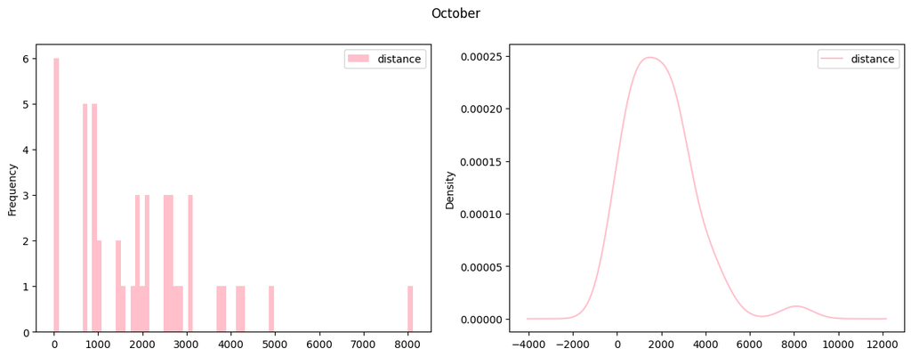

```python
# single
for m in months:
    fig, axs = plt.subplots(1, 2, figsize=(15,5))
    single_month = single.loc[single['month'] == m]
    single_month['distance'].plot(kind='hist',bins=75, ax=axs[0], color="pink", legend=True)
    single_month['distance'].plot(kind='density', ax=axs[1], color="pink", legend=True)
    fig.suptitle(month_names[m])
```

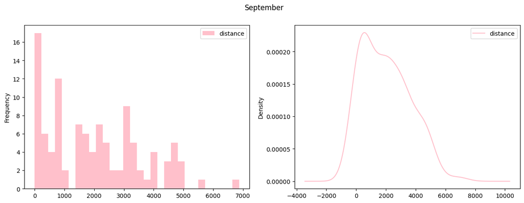

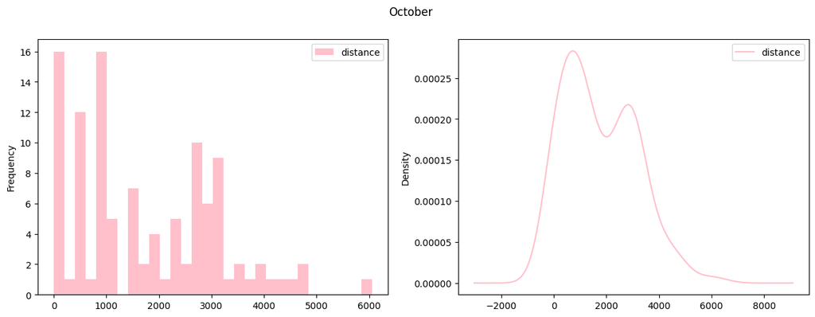

```python
# savonia
# Only values in months 9 and 10.
months = [9, 10]
for m in months:
    fig, axs = plt.subplots(1, 2, figsize=(15,5))
    savonia_month = savonia.loc[savonia['month'] == m]
    savonia_month['distance'].plot(kind='hist',bins=30, ax=axs[0], color="pink", legend=True)
    savonia_month['distance'].plot(kind='density', ax=axs[1], color="pink", legend=True)
    fig.suptitle(month_names[m])
```

### Visualisation of the distribution of net energy gain

|  | net_energy |
| --- | --- |
| count | 1989.000000 |
| mean | -7.411815 |
| std | 11.897946 |
| min | -121.000000 |
| 25% | -12.200000 |
| 50% | -3.100000 |
| 75% | 0.000000 |
| max | 21.900000 |

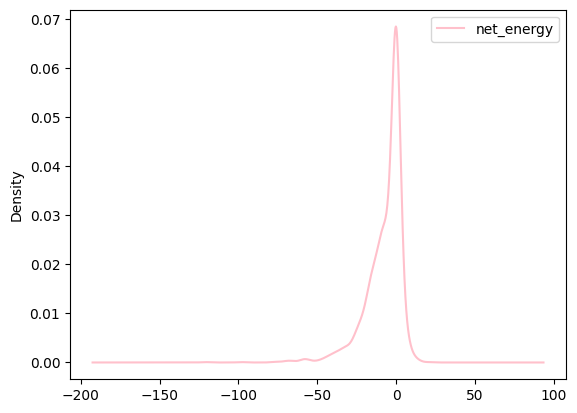

```python
# net energy gain is the difference between the energy collected and consumed during a trip
data['net_energy'] = data['energy_collected'] - data['energy_used']
display(pd.DataFrame(data['net_energy']).plot(kind='density', color="pink"))
display(data['net_energy'].describe().to_frame())
```

Seems that energy gain is mosly negative. People use more energy than they can generate.

### Visualisation of the pairwise relationships between the quantitative variables

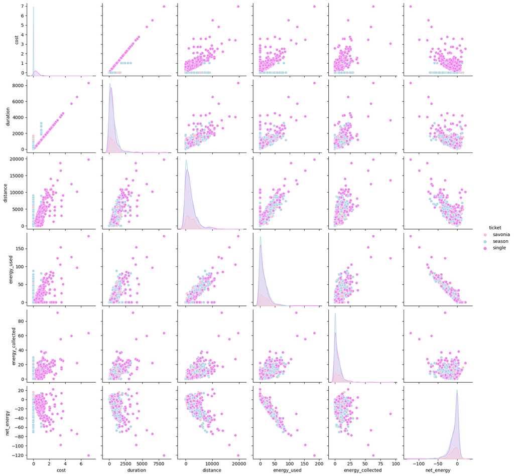

```python
del data['index']
sns.pairplot(data, hue='ticket', palette=['pink', 'lightblue', 'violet'])
```

## Hypothesis testing

### Explain what the p-value of a statistical test means and how it can be used to make conclusions.

P-value indicates how likely a null hypothesis is. Smaller the p-value is higher the change that the null hypothesis is not true. If p-value is smaller than 0.05 null hypothesis should be rejected.

### Is there statistical evidence to claim that the travel times tend to be shorter or longer for the single than for the season ticket type?

```
Single: ShapiroResult(statistic=0.6379894018173218, pvalue=1.6262951496522027e-39)
```

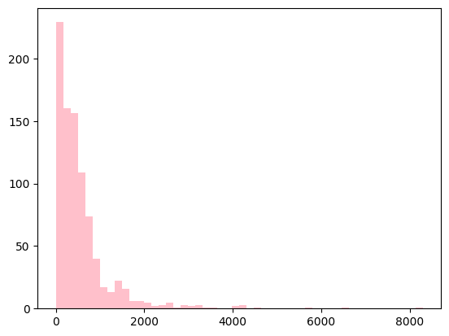

```
Season: ShapiroResult(statistic=0.8867703676223755, pvalue=5.591184292993611e-25)
```

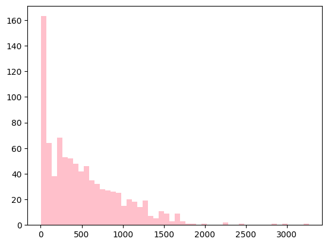

```
MannwhitneyuResult(statistic=382124.5, pvalue=0.33566332411271116)
Single: Mean: 560.9762174405436 Median: 379.0
Season: 516.5815523059617 Median: 414.0
```

```python
#single
single_dur = single[single['duration'] >= 0]['duration']
print("Single:", stats.shapiro(single_dur))
plt.hist(single_dur, bins = 50, color='pink')
plt.show()

#season
season_dur = season['duration']
print("Season:", stats.shapiro(season_dur))
plt.hist(season_dur, bins = 50, color='pink')
plt.show()

# these are not normally distributed and unpaired
# so we use Mann-Whitney U test
test = stats.mannwhitneyu(single_dur, season_dur)
print(test)

# means
print("Single:", "Mean:", single_dur.mean(), "Median:", single_dur.median())
print("Season:", season_dur.mean(), "Median:", season_dur.median())
```

### Is there statistical evidence to claim that the single and savonia ticket types differ with respect to how often the electric assistance is used?

```python
# comparing categorial values -> Chi-Pearson squared test
# concat data into one set that can be crosstabed
chi_data = pd.concat([single['assistance'],savonia['assistance']], keys=['single', 'savonia']).reset_index()
display(chi_data)

# crosstab the chi_data
cros = pd.crosstab(index=chi_data['assistance'], columns=chi_data['level_0'])
display(cros)

#Chi-Pearson square test
chi = stats.chi2_contingency(cros)
print("p =", chi[1])
```

|  | level_0 | level_1 | assistance |
| --- | --- | --- | --- |
| 0 | single | 0 | 1 |
| 1 | single | 1 | 0 |
| 2 | single | 2 | 0 |
| 3 | single | 3 | 1 |
| 4 | single | 4 | 1 |
| ... | ... | ... | ... |
| 1095 | savonia | 212 | 1 |
| 1096 | savonia | 213 | 1 |
| 1097 | savonia | 214 | 1 |
| 1098 | savonia | 215 | 1 |
| 1099 | savonia | 216 | 1 |

1100 rows × 3 columns

| level_0 assistance | savonia | single |
| --- | --- | --- |
| 0 | 9 | 191 |
| 1 | 208 | 692 |

```
p = 3.993990459037074e-09
```

Based on the p-value single and savonia clearly differ on how often the assistance is used. Chi-Pearson square test was used to get the P-value as both (ticket and assitance) are categorial.

### Is there statistical evidence to claim that the travel distances tend to be shorter or longer during one month than during the others?

```python
# month selection
april = data.loc[data['month'] == 4].reset_index()
may = data.loc[data['month'] == 5].reset_index()
june = data.loc[data['month'] == 6].reset_index()
july = data.loc[data['month'] == 7].reset_index()
august = data.loc[data['month'] == 8].reset_index()
september = data.loc[data['month'] == 9].reset_index()
october = data.loc[data['month'] == 10].reset_index()

#make distance dataframe with months as columns
d = {'april': april.distance,
    'may': may.distance,
    'june': june.distance,
    'july': july.distance,
    'august': august.distance,
    'september': september.distance,
    'october': october.distance}
months = pd.DataFrame(data=d)
display(months)

# Description
print("Description:")
months.describe()
```

|  | april | may | june | july | august | september | october |
| --- | --- | --- | --- | --- | --- | --- | --- |
| 0 | 700.0 | 720.0 | 3130 | 0.0 | 1230.0 | 5010.0 | 3320.0 |
| 1 | 4260.0 | 710.0 | 0 | 820.0 | 2670.0 | 0.0 | 930.0 |
| 2 | 0.0 | 4870.0 | 3070 | 750.0 | 0.0 | 0.0 | 1870.0 |
| 3 | 2870.0 | 3130.0 | 60 | 1600.0 | 1610.0 | 740.0 | 0.0 |
| 4 | 2640.0 | 2590.0 | 3060 | 3340.0 | 8710.0 | 0.0 | 60.0 |
| ... | ... | ... | ... | ... | ... | ... | ... |
| 483 | NaN | NaN | 2640 | NaN | NaN | NaN | NaN |
| 484 | NaN | NaN | 8430 | NaN | NaN | NaN | NaN |
| 485 | NaN | NaN | 1500 | NaN | NaN | NaN | NaN |
| 486 | NaN | NaN | 2220 | NaN | NaN | NaN | NaN |
| 487 | NaN | NaN | 1910 | NaN | NaN | NaN | NaN |

488 rows × 7 columns

```
Description:
```

|  | april | may | june | july | august | september | october |
| --- | --- | --- | --- | --- | --- | --- | --- |
| count | 43.000000 | 374.000000 | 488.000000 | 406.000000 | 227.000000 | 256.000000 | 195.000000 |
| mean | 1662.325581 | 1383.181818 | 1784.385246 | 1643.349754 | 1843.524229 | 2149.804688 | 1811.743590 |
| std | 1809.930066 | 1825.802636 | 2285.901624 | 2017.076019 | 1962.260279 | 2083.119541 | 1482.931075 |
| min | 0.000000 | 0.000000 | 0.000000 | 0.000000 | 0.000000 | 0.000000 | 0.000000 |
| 25% | 0.000000 | 0.000000 | 30.000000 | 55.000000 | 15.000000 | 707.500000 | 705.000000 |
| 50% | 1130.000000 | 885.000000 | 1130.000000 | 965.000000 | 1430.000000 | 1830.000000 | 1480.000000 |
| 75% | 2970.000000 | 1950.000000 | 2220.000000 | 2195.000000 | 2755.000000 | 3005.000000 | 2785.000000 |
| max | 8370.000000 | 12430.000000 | 18690.000000 | 19740.000000 | 10800.000000 | 16440.000000 | 8110.000000 |

```python
# Multiple non-normally distributed variables
# -> Kruskal-Wallis test

# all
kruskal = stats.kruskal(april.distance, may.distance, june.distance, july.distance, august.distance, september.distance, october.distance).pvalue
print("All:", kruskal)

# based on description months chosen that have similar means and standad diviations
kruskal = stats.kruskal(april.distance, june.distance, july.distance, august.distance).pvalue
print("April/June/July/August:", kruskal)

# testing if may fits in
kruskal = stats.kruskal(may.distance, april.distance, june.distance, july.distance, august.distance).pvalue
print("MAY/April/June/July/August:", kruskal)

# testing if september fits in
kruskal = stats.kruskal(september.distance, april.distance, june.distance, july.distance, august.distance).pvalue
print("SEPTEMBER/April/June/July/August:", kruskal)

# testing if october fits in
kruskal = stats.kruskal(october.distance, april.distance, june.distance, july.distance, august.distance).pvalue
print("OCTOBER/April/June/July/August:", kruskal)
```

```
All: 2.2320188251501713e-09
April/June/July/August: 0.5108134257842469
MAY/April/June/July/August: 0.0022829057652614297
SEPTEMBER/April/June/July/August: 0.0002820028141350359
OCTOBER/April/June/July/August: 0.04758461109041475
```

Kruskal-Wallis of all months tells us that there is statistical evidence to suggest a difference in distances between the months. Based on description april, june, july and, august have similar standard diviation and means. This is why I chose them form the first test. Kruskal-Wallis confirms this with p-value of 0.51.

I add may, september and october alternately to the Kruskal-Wallis test with the months listed above. This shows that all these months have a notable difference. October's mean is the same as the compared months but standard deviation is is smaller. Distances are not notably longer or shorter.

May has shortest travel distances and september the longest based on the means.

### Is there statistical evidence to claim that the distance travelled correlates with the energy consumed when the electric assistance is enabled?

```python
# lets make a dataframe where assistance = 1
posDist_posAsst = data.loc[data['assistance'] == 1]

# values are not normally distributed
# -> Spearman correlation
posDist_posAsst.corr(method ='spearman')
```

|  | cost | duration | distance | energy_used | energy_collected | net_energy |
| --- | --- | --- | --- | --- | --- | --- |
| cost | 1.000000 | 0.181913 | 0.212046 | 0.169557 | 0.177606 | -0.120186 |
| duration | 0.181913 | 1.000000 | 0.867369 | 0.853751 | 0.749212 | -0.720501 |
| distance | 0.212046 | 0.867369 | 1.000000 | 0.946728 | 0.847482 | -0.785720 |
| energy_used | 0.169557 | 0.853751 | 0.946728 | 1.000000 | 0.769512 | -0.905071 |
| energy_collected | 0.177606 | 0.749212 | 0.847482 | 0.769512 | 1.000000 | -0.464642 |
| net_energy | -0.120186 | -0.720501 | -0.785720 | -0.905071 | -0.464642 | 1.000000 |

There is a clear positive correlation between distance and energy consumed **0.946728**. This is intuitively very expectable result. Cyclist use more energy on longer journeys.

### Is there statistical evidence to claim that the savonia and season ticket types differ with respect to how often the trip ends where it started?

```python
# how many rows in total of season and savonia tickets
print("Season shape:", season.shape)
print("Savonia shape:", savonia.shape)

season_start_end_same = season.loc[season.location_from == season.location_to]
savonia_start_end_same = savonia.loc[savonia.location_from == savonia.location_to]
print("Season shape (where start and location are same):", season_start_end_same.shape)
print("Savonia shape (where start and location are same):", savonia_start_end_same.shape)

print("Probability of starting and finnishing in the same location")
print("Season:", season_start_end_same.shape[0]/season.shape[0])
print("Savonia:", savonia_start_end_same.shape[0]/savonia.shape[0])
```

```
Season shape: (889, 12)
Savonia shape: (217, 12)
Season shape (where start and location are same): (363, 12)
Savonia shape (where start and location are same): (75, 12)
Probability of starting and finnishing in the same location
Season: 0.40832395950506184
Savonia: 0.3456221198156682
```

Season ticket users are only ~6% more likely to finish their joyrney in the location they started it so no notable difference.

### Is there statistical evidence to claim that the travel time correlates with the average speed at which the trip is made?

```python
# average speed in meters per second
data['avg_speed'] = data['distance'] / data['duration']
display(data)
```

|  | ticket | cost | month | location_from | location_to | duration | distance | assistance | energy_used | energy_collected | net_energy | avg_speed |
| --- | --- | --- | --- | --- | --- | --- | --- | --- | --- | --- | --- | --- |
| 0 | season | 0.00 | 7 | TEATTERI | TEATTERI | 3 | 0 | 0 | 0.0 | 0.0 | 0.0 | 0.000000 |
| 1 | single | 0.35 | 7 | TORI | TEATTERI | 416 | 820 | 1 | 7.5 | 0.6 | -6.9 | 1.971154 |
| 2 | season | 0.00 | 8 | TORI | SATAMA | 721 | 1230 | 0 | 0.0 | 2.1 | 2.1 | 1.705964 |
| 3 | single | 0.25 | 5 | TEATTERI | TORI | 261 | 720 | 0 | 0.0 | 1.2 | 1.2 | 2.758621 |
| 4 | season | 0.00 | 5 | TEATTERI | TORI | 382 | 710 | 1 | 3.3 | 0.9 | -2.4 | 1.858639 |
| ... | ... | ... | ... | ... | ... | ... | ... | ... | ... | ... | ... | ... |
| 1984 | single | 0.40 | 8 | KYS | TORI | 420 | 1940 | 1 | 10.3 | 6.0 | -4.3 | 4.619048 |
| 1985 | single | 0.65 | 7 | VÄINÖLÄNNIEMI | SATAMA | 720 | 1020 | 0 | 0.0 | 0.0 | 0.0 | 1.416667 |
| 1986 | single | 0.15 | 9 | TORI | TEATTERI | 172 | 730 | 1 | 6.6 | 0.3 | -6.3 | 4.244186 |
| 1987 | season | 0.00 | 7 | SNELLMANIA | MICROTEKNIA | 211 | 450 | 0 | 0.0 | 0.3 | 0.3 | 2.132701 |
| 1988 | single | 1.00 | 5 | TEATTERI | TORI | 1166 | 680 | 1 | 3.4 | 2.4 | -1.0 | 0.583190 |

1989 rows × 12 columns

```python
print(stats.shapiro(data.duration))
print(stats.shapiro(data.avg_speed))

# the columns we are interested in are not normally distributed
# ->spearman
data.corr(method="spearman")
```

```
ShapiroResult(statistic=0.7284510135650635, pvalue=0.0)
ShapiroResult(statistic=0.9092564582824707, pvalue=6.98452074230519e-33)
```

|  | cost | duration | distance | energy_used | energy_collected | net_energy | avg_speed |
| --- | --- | --- | --- | --- | --- | --- | --- |
| cost | 1.000000 | 0.190905 | 0.207013 | 0.117381 | 0.169368 | -0.060857 | 0.142077 |
| duration | 0.190905 | 1.000000 | 0.882530 | 0.753173 | 0.768773 | -0.588837 | 0.509743 |
| distance | 0.207013 | 0.882530 | 1.000000 | 0.850793 | 0.865857 | -0.656951 | 0.773587 |
| energy_used | 0.117381 | 0.753173 | 0.850793 | 1.000000 | 0.748948 | -0.897392 | 0.674766 |
| energy_collected | 0.169368 | 0.768773 | 0.865857 | 0.748948 | 1.000000 | -0.435416 | 0.691057 |
| net_energy | -0.060857 | -0.588837 | -0.656951 | -0.897392 | -0.435416 | 1.000000 | -0.490265 |
| avg_speed | 0.142077 | 0.509743 | 0.773587 | 0.674766 | 0.691057 | -0.490265 | 1.000000 |

The correlation between duration and average speed is **0.509743**. It means that cyclist that travel longer tend to also go faster.